# Predicting the manner of performing the exercise

## Summary

More and more people use devices such as Jawbone Up, Nike FuelBand, and Fitbit to quantify how much of a particular activity they do, but they rarely quantify how well they do it. The goal of this Project is to (on the basis of data from accelerometers on the belt, forearm, arm, and dumbbell collected from 6 participants, that were asked to perform barbell lifts correctly and incorrectly in 5 different ways) predict the manner in which they did the exercise.

## Getting the data

First we download the data from the http://groupware.les.inf.puc-rio.br/har#weight_lifting_exercises site $^1$:

```r
echo <- FALSE
if(!file.exists("./pml-training.csv"))
{
    print("Data will be downloaded")
    url <- "https://d396qusza40orc.cloudfront.net/predmachlearn/pml-training.csv"
    download.file(url, "./pml-training.csv", method = "curl")
} else echo <- TRUE
if(!file.exists("./pml-testing.csv"))
{
    url <- "https://d396qusza40orc.cloudfront.net/predmachlearn/pml-testing.csv"
    download.file(url, "./pml-testing.csv", method = "curl")
} else echo <- TRUE
if (echo) print("Data was already downloaded ...")
```

## Exploratory data analysis

Then we read the data:

```r
training <- read.csv("./pml-training.csv")
testing <- read.csv("./pml-testing.csv")
```

and do some exploratory data analysis$^2$:

```r
summary(training)
summary(testing)
```

## Preparing data

From exploratory data analysis we see a lot of blank values and “#DIV/0!” fields so we replace both with NA-s.

```r
training[training==""] <- "NA"
training[training=="#DIV/0!"] <- "NA"
```

## Building the model

We want that our report is reproducible so we set the seed.

```r
set.seed(965)
```

First we try to build the model with “rpart” package (which implements “Recursive partitioning for classification, regression and survival trees”) and all variables included:

```r
modFit <- train(classe ~ .,method="rpart",data=training)
```

But this build is not successful because “Every row has at least one missing value”, so we must exclude the variables with more than 90% of NA-s.

```r
percNA <- colSums(is.na(training))/dim(training)[1]
tr <- training[,percNA<0.9]
not_cc <- sum(complete.cases(tr))-dim(tr)[1]
print (not_cc)
```

```
## [1] 0
```

And try building the model again:

```r
modFit1 <- train(classe ~ .,method="rpart",data=tr)
```

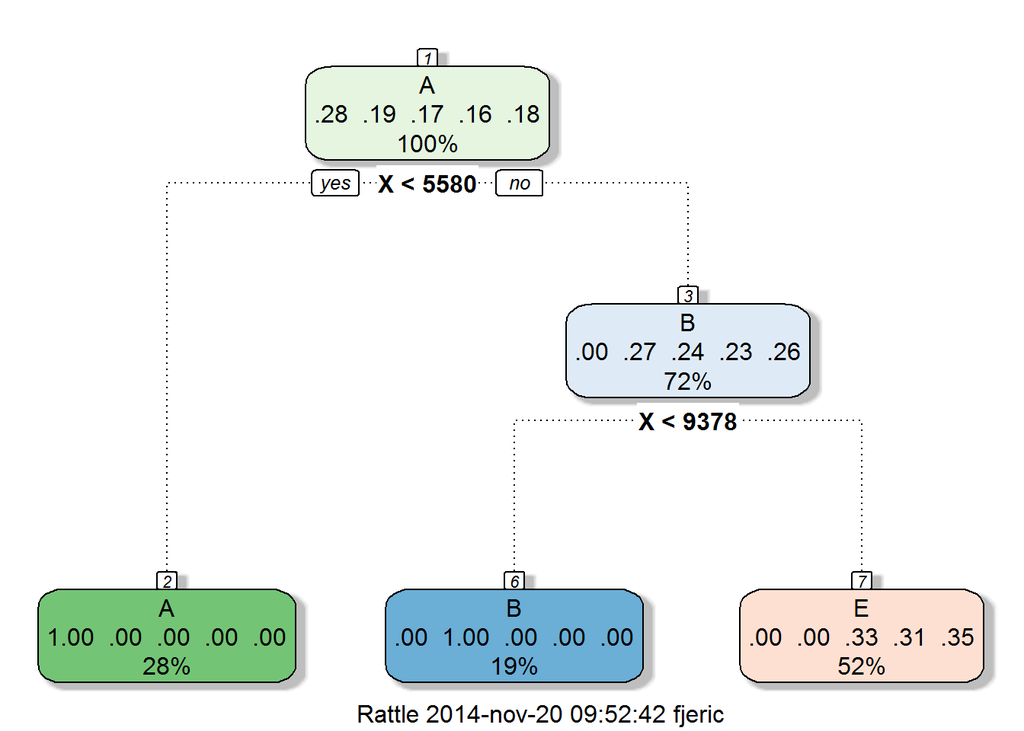

```r
plot1 <-fancyRpartPlot(modFit1$finalModel)
```

We see that this model is not appropriate because is based only on “X” variable (index) and never predict “D” classe. So we eliminate the “X” variable from our predictors.

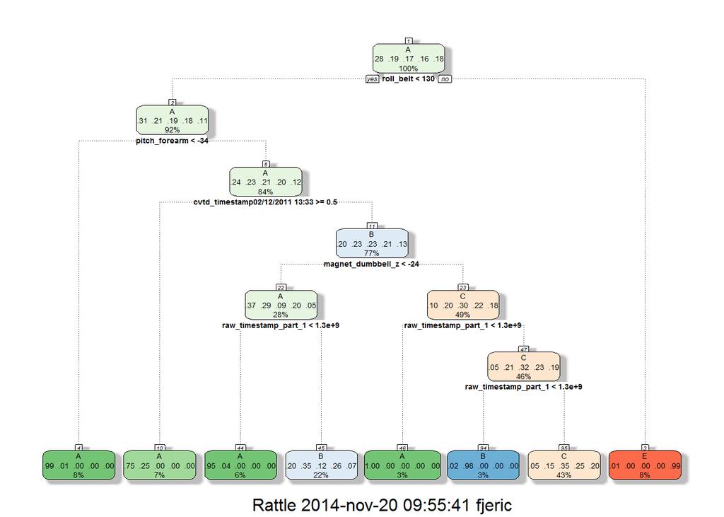

```r
modFit2 <- train(classe ~ . - X,method="rpart",data=tr)
plot2 <- fancyRpartPlot(modFit2$finalModel)
```

This model uses as predictor timestamps, and because timestamps are not valuable predictor we also eliminate all timestamps predictors:

```r
modFit3 <- train(classe ~ . - X-raw_timestamp_part_1-raw_timestamp_part_2-cvtd_timestamp,method="rpart",data=tr)
fM3 <- modFit3$finalModel
print(fM3)
```

```
## n= 19622
##
## node), split, n, loss, yval, (yprob)
##       * denotes terminal node
##
##  1) root 19622 14042 A (0.28 0.19 0.17 0.16 0.18)
##    2) roll_belt< 130.5 17977 12411 A (0.31 0.21 0.19 0.18 0.11)
##      4) pitch_forearm< -33.95 1578    10 A (0.99 0.0063 0 0 0) *
##      5) pitch_forearm>=-33.95 16399 12401 A (0.24 0.23 0.21 0.2 0.12)
##       10) magnet_dumbbell_y< 439.5 13870  9953 A (0.28 0.18 0.24 0.19 0.11)
##         20) roll_forearm< 123.5 8643  5131 A (0.41 0.18 0.18 0.17 0.061) *
##         21) roll_forearm>=123.5 5227  3500 C (0.077 0.18 0.33 0.23 0.18) *
##       11) magnet_dumbbell_y>=439.5 2529  1243 B (0.032 0.51 0.043 0.22 0.19) *
##    3) roll_belt>=130.5 1645    14 E (0.0085 0 0 0 0.99) *
```

## Cross Validation

For validating the above model the Random sub sampling was used. We calculated the Accuracy for 1000 random samples of size 20 (the size of testing set) from training set and look the Accuracy Mean and Standard Deviation.

```r
accuracy1 <- replicate(1000,
                 {validating <- training[sample(nrow(training),20),]
                    predictions <- predict(modFit3,newdata=validating)
                    cm <- confusionMatrix(predictions,validating$classe)
                    accuracy <- cm$overall[1]
                  })
acc_mean1 <- mean(accuracy1)
print (acc_mean1)
```

```
## [1] 0.49425
```

```r
acc_sd1 <-sd(accuracy1)
print (acc_sd1)
```

```
## [1] 0.112125
```

We see that Accuracy for this model is very low, so we must find better tool for building predicting model.

## Better Model

So for building the better model we used the “ctree” tool from party package.

```r
modFit4 <- train(classe ~ .-X-raw_timestamp_part_1-raw_timestamp_part_2-cvtd_timestamp,method="ctree",data=tr)
fM4 <- modFit4$finalModel
```

The Accuracy of this model$^3$ is over 90%:

```r
accuracy2 <- replicate(1000,
                 {validating <- training[sample(nrow(training),20),]
                    predictions <- predict(modFit4,newdata=validating)
                    cm <- confusionMatrix(predictions,validating$classe)
                    accuracy <- cm$overall[1]
                  })
acc_mean2 <- mean(accuracy2)
print (acc_mean2)
```

```
## [1] 0.94605
```

```r
acc_sd2 <-sd(accuracy2)
print (acc_sd2)
```

```
## [1] 0.0508378
```

## Out of Sample Error

One of the common error measures is Accuracy. In previous paragraph we calculated Accuracy as the In of Sample Error. Because the Out of Sample Errors are always greater than In of Sample Errors we can estimate that Accuracy of the testing sample will be lower than 0.94605 $\pm$ 0.0508378.

## References

$^1$ Velloso, E.; Bulling, A.; Gellersen, H.; Ugulino, W.; Fuks, H. Qualitative Activity Recognition of Weight Lifting Exercises. Proceedings of 4th International Conference in Cooperation with SIGCHI (Augmented Human ’13) . Stuttgart, Germany: ACM SIGCHI, 2013.

## Appendix

$^2$ Exploratory Data Analysis

```r
summary(training)
```

```
##        X            user_name    raw_timestamp_part_1 raw_timestamp_part_2
##  Min.   :    1   adelmo  :3892   Min.   :1.322e+09    Min.   :   294
##  1st Qu.: 4906   carlitos:3112   1st Qu.:1.323e+09    1st Qu.:252912
##  Median : 9812   charles :3536   Median :1.323e+09    Median :496380
##  Mean   : 9812   eurico  :3070   Mean   :1.323e+09    Mean   :500656
##  3rd Qu.:14717   jeremy  :3402   3rd Qu.:1.323e+09    3rd Qu.:751891
##  Max.   :19622   pedro   :2610   Max.   :1.323e+09    Max.   :998801
##
##           cvtd_timestamp  new_window    num_window      roll_belt
##  28/11/2011 14:14: 1498   no :19216   Min.   :  1.0   Min.   :-28.90
##  05/12/2011 11:24: 1497   yes:  406   1st Qu.:222.0   1st Qu.:  1.10
##  30/11/2011 17:11: 1440               Median :424.0   Median :113.00
##  05/12/2011 11:25: 1425               Mean   :430.6   Mean   : 64.41
##  02/12/2011 14:57: 1380               3rd Qu.:644.0   3rd Qu.:123.00
##  02/12/2011 13:34: 1375               Max.   :864.0   Max.   :162.00
##  (Other)         :11007
##    pitch_belt          yaw_belt       total_accel_belt kurtosis_roll_belt
##  Min.   :-55.8000   Min.   :-180.00   Min.   : 0.00    -1.908453:    2
##  1st Qu.:  1.7600   1st Qu.: -88.30   1st Qu.: 3.00    -0.016850:    1
##  Median :  5.2800   Median : -13.00   Median :17.00    -0.021024:    1
##  Mean   :  0.3053   Mean   : -11.21   Mean   :11.31    -0.025513:    1
##  3rd Qu.: 14.9000   3rd Qu.:  12.90   3rd Qu.:18.00    -0.033935:    1
##  Max.   : 60.3000   Max.   : 179.00   Max.   :29.00    (Other)  :  390
##                                                        NA's     :19226
##  kurtosis_picth_belt kurtosis_yaw_belt skewness_roll_belt
##  47.000000:    4            :    0     0.000000 :    4
##  -0.150950:    3     #DIV/0!:    0     0.422463 :    2
##  -0.684748:    3     NA's   :19622     -0.003095:    1
##  -1.750749:    3                       -0.010002:    1
##  -1.851307:    3                       -0.014020:    1
##  (Other)  :  358                       (Other)  :  388
##  NA's     :19248                       NA's     :19225
##  skewness_roll_belt.1 skewness_yaw_belt max_roll_belt     max_picth_belt
##  0.000000 :    4             :    0     Min.   :-94.300   Min.   : 3.00
##  -2.156553:    3      #DIV/0!:    0     1st Qu.:-88.000   1st Qu.: 5.00
##  -3.072669:    3      NA's   :19622     Median : -5.100   Median :18.00
##  -6.324555:    3                        Mean   : -6.667   Mean   :12.92
##  6.855655 :    3                        3rd Qu.: 18.500   3rd Qu.:19.00
##  (Other)  :  358                        Max.   :180.000   Max.   :30.00
##  NA's     :19248                        NA's   :19216     NA's   :19216
```

[output cut: 313 more lines]

```
##  Min.   :-446.00   Min.   :-1280.0   Min.   :-896.0   Min.   :-973.0
##  1st Qu.:-182.00   1st Qu.: -616.0   1st Qu.:   2.0   1st Qu.: 191.0
##  Median : -39.00   Median : -378.0   Median : 591.0   Median : 511.0
##  Mean   : -55.29   Mean   : -312.6   Mean   : 380.1   Mean   : 393.6
##  3rd Qu.:  26.00   3rd Qu.:  -73.0   3rd Qu.: 737.0   3rd Qu.: 653.0
##  Max.   : 291.00   Max.   :  672.0   Max.   :1480.0   Max.   :1090.0
##
##  classe
##  A:5580
##  B:3797
##  C:3422
##  D:3216
##  E:3607
##
##
```

```r
summary(testing)
```

```
##        X            user_name raw_timestamp_part_1 raw_timestamp_part_2
##  Min.   : 1.00   adelmo  :1   Min.   :1.322e+09    Min.   : 36553
##  1st Qu.: 5.75   carlitos:3   1st Qu.:1.323e+09    1st Qu.:268655
##  Median :10.50   charles :1   Median :1.323e+09    Median :530706
##  Mean   :10.50   eurico  :4   Mean   :1.323e+09    Mean   :512167
##  3rd Qu.:15.25   jeremy  :8   3rd Qu.:1.323e+09    3rd Qu.:787738
##  Max.   :20.00   pedro   :3   Max.   :1.323e+09    Max.   :920315
##
##           cvtd_timestamp new_window   num_window      roll_belt
##  30/11/2011 17:11:4      no:20      Min.   : 48.0   Min.   : -5.9200
##  05/12/2011 11:24:3                 1st Qu.:250.0   1st Qu.:  0.9075
##  30/11/2011 17:12:3                 Median :384.5   Median :  1.1100
##  05/12/2011 14:23:2                 Mean   :379.6   Mean   : 31.3055
##  28/11/2011 14:14:2                 3rd Qu.:467.0   3rd Qu.: 32.5050
##  02/12/2011 13:33:1                 Max.   :859.0   Max.   :129.0000
##  (Other)         :5
##    pitch_belt         yaw_belt      total_accel_belt kurtosis_roll_belt
##  Min.   :-41.600   Min.   :-93.70   Min.   : 2.00    Mode:logical
##  1st Qu.:  3.013   1st Qu.:-88.62   1st Qu.: 3.00    NA's:20
##  Median :  4.655   Median :-87.85   Median : 4.00
##  Mean   :  5.824   Mean   :-59.30   Mean   : 7.55
##  3rd Qu.:  6.135   3rd Qu.:-63.50   3rd Qu.: 8.00
##  Max.   : 27.800   Max.   :162.00   Max.   :21.00
##
##  kurtosis_picth_belt kurtosis_yaw_belt skewness_roll_belt
##  Mode:logical        Mode:logical      Mode:logical
##  NA's:20             NA's:20           NA's:20
##
##
##
##
##
##  skewness_roll_belt.1 skewness_yaw_belt max_roll_belt  max_picth_belt
##  Mode:logical         Mode:logical      Mode:logical   Mode:logical
##  NA's:20              NA's:20           NA's:20        NA's:20
##
##
##
##
##
```

[output cut: 289 more lines]

```
##  Min.   :-1.2600   Min.   :-212.0   Min.   :-331.0   Min.   :-282.0
##  1st Qu.:-0.0975   1st Qu.:-114.8   1st Qu.:   8.5   1st Qu.:-199.0
##  Median : 0.2300   Median :  86.0   Median : 138.0   Median :-148.5
##  Mean   : 0.2610   Mean   :  38.8   Mean   : 125.3   Mean   : -93.7
##  3rd Qu.: 0.7625   3rd Qu.: 166.2   3rd Qu.: 268.0   3rd Qu.: -31.0
##  Max.   : 1.8000   Max.   : 232.0   Max.   : 406.0   Max.   : 179.0
##
##  magnet_forearm_x magnet_forearm_y magnet_forearm_z   problem_id
##  Min.   :-714.0   Min.   :-787.0   Min.   :-32.0    Min.   : 1.00
##  1st Qu.:-427.2   1st Qu.:-328.8   1st Qu.:275.2    1st Qu.: 5.75
##  Median :-189.5   Median : 487.0   Median :491.5    Median :10.50
##  Mean   :-159.2   Mean   : 191.8   Mean   :460.2    Mean   :10.50
##  3rd Qu.:  41.5   3rd Qu.: 720.8   3rd Qu.:661.5    3rd Qu.:15.25
##  Max.   : 532.0   Max.   : 800.0   Max.   :884.0    Max.   :20.00
##
```

$^3$ Final Model

```r
print(fM4)
```

```
##
##   Conditional inference tree with 570 terminal nodes
##
## Response:  .outcome
## Inputs:  user_namecarlitos, user_namecharles, user_nameeurico, user_namejeremy, user_namepedro, new_windowyes, num_window, roll_belt, pitch_belt, yaw_belt, total_accel_belt, gyros_belt_x, gyros_belt_y, gyros_belt_z, accel_belt_x, accel_belt_y, accel_belt_z, magnet_belt_x, magnet_belt_y, magnet_be…
## Number of observations:  19622
##
## 1) pitch_forearm <= -34; criterion = 1, statistic = 3648.881
##   2) gyros_arm_x <= 0.88; criterion = 1, statistic = 120.393
##     3)*  weights = 1515
##   2) gyros_arm_x > 0.88
##     4) gyros_dumbbell_y <= 0.1; criterion = 1, statistic = 28.439
##       5)*  weights = 48
##     4) gyros_dumbbell_y > 0.1
##       6)*  weights = 15
## 1) pitch_forearm > -34
##   7) magnet_belt_y <= 555; criterion = 1, statistic = 2038.759
##     8) user_nameeurico <= 0; criterion = 1, statistic = 1186.329
##       9) roll_arm <= -126; criterion = 0.912, statistic = 10.007
##         10)*  weights = 13
##       9) roll_arm > -126
##         11)*  weights = 1130
##     8) user_nameeurico > 0
##       12) pitch_belt <= 4.7; criterion = 1, statistic = 299.998
##         13) accel_dumbbell_x <= 46; criterion = 1, statistic = 99.601
##           14) magnet_belt_x <= 51; criterion = 1, statistic = 25.086
##             15)*  weights = 8
##           14) magnet_belt_x > 51
##             16)*  weights = 258
##         13) accel_dumbbell_x > 46
##           17)*  weights = 7
##       12) pitch_belt > 4.7
##         18)*  weights = 49
##   7) magnet_belt_y > 555
##     19) roll_dumbbell <= -95.20629; criterion = 1, statistic = 1713.464
##       20) num_window <= 172; criterion = 1, statistic = 410.802
##         21) user_namepedro <= 0; criterion = 1, statistic = 282
##           22) pitch_belt <= 11.7; criterion = 1, statistic = 23.265
##             23)*  weights = 184
##           22) pitch_belt > 11.7
```

[output cut: 1660 more lines]

```
##                         1130)*  weights = 16
##           857) magnet_dumbbell_z > 152
##             1131) magnet_dumbbell_x <= -220; criterion = 1, statistic = 78.764
##               1132) roll_dumbbell <= 36.58797; criterion = 1, statistic = 59.261
##                 1133)*  weights = 8
##               1132) roll_dumbbell > 36.58797
##                 1134) yaw_dumbbell <= 54.23892; criterion = 1, statistic = 46.398
##                   1135)*  weights = 7
##                 1134) yaw_dumbbell > 54.23892
##                   1136)*  weights = 88
##             1131) magnet_dumbbell_x > -220
##               1137) num_window <= 239; criterion = 1, statistic = 21
##                 1138)*  weights = 13
##               1137) num_window > 239
##                 1139)*  weights = 9
```